# Detecting model misfit with posterior predictive checks

Jonah Gabry, Aki Vehtari

Last modified 2026-10-22.

# Setup

**Load packages**

```r
library(rstan)
library(ggplot2)
library(bayesplot)
theme_set(bayesplot::theme_default(base_family = "sans"))
library(loo)
library(rprojroot)
root<-has_file(".BDA_R_demos_root")$make_fix_file()
```

# 1 Load and examine data

```r
source(root("demos_rstan/ppc", "count-data.R"))
print(N)
```

```
[1] 500
```

```r
print(y)
```

```
  [1] 0 3 5 0 4 7 4 2 3 6 7 0 0 3 7 5 5 0 4 0 4 4 6 3 7 5 3 0 0 2 0 1 0 1 5 4 4
 [38] 2 3 6 4 5 0 7 7 4 4 4 0 6 1 5 6 5 6 7 3 6 2 3 0 2 0 6 6 0 3 4 4 5 5 0 5 7
 [75] 5 5 6 4 2 3 4 6 4 6 6 4 0 6 5 5 7 0 1 6 7 0 5 0 0 5 6 5 1 0 7 1 2 6 5 4 0
[112] 4 0 4 4 6 3 0 0 3 3 4 2 5 3 4 3 2 5 2 4 4 0 2 7 5 7 5 5 7 7 0 4 6 0 4 6 7
[149] 4 0 4 1 5 0 3 5 7 6 0 5 5 6 7 6 7 3 4 3 7 7 2 5 4 5 5 0 6 2 4 5 4 0 0 5 5
[186] 7 7 0 3 0 3 3 6 1 4 2 0 4 7 5 5 0 3 7 0 6 6 4 1 6 7 6 0 3 6 4 7 0 5 5 4 0
[223] 0 2 4 6 0 5 0 2 7 2 7 5 4 6 2 4 0 4 0 0 3 5 4 3 5 5 7 7 0 6 4 5 1 5 3 5 5
[260] 5 0 2 7 6 2 3 2 5 4 7 6 7 3 3 4 4 6 4 6 7 1 5 6 3 3 6 3 4 0 7 0 3 6 5 0 0
[297] 0 5 4 4 0 4 7 5 5 3 3 0 0 5 4 0 7 6 0 6 2 0 6 1 0 4 0 4 3 0 4 5 5 7 6 6 5
[334] 4 7 0 6 4 7 7 5 0 1 4 7 6 4 5 4 7 2 5 2 6 3 2 7 4 3 4 6 6 6 6 7 1 0 0 7 7
[371] 4 2 4 5 5 7 4 1 7 6 5 6 5 4 0 0 7 0 0 5 6 6 3 6 0 0 0 4 4 3 0 7 5 4 2 7 0
[408] 4 0 0 2 4 5 0 4 2 5 2 0 6 6 3 6 0 2 5 0 0 0 6 0 0 6 5 4 6 4 5 5 4 0 3 4 3
[445] 3 5 3 4 5 7 0 0 1 4 6 3 5 7 6 6 5 0 5 4 0 0 2 6 0 6 0 4 5 6 3 4 2 3 4 0 5
[482] 0 0 0 0 3 4 7 6 7 7 3 4 4 7 4 5 2 5 6
```

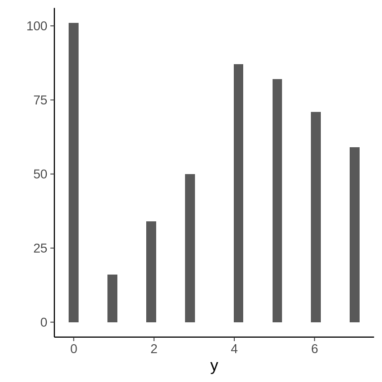

```r
qplot(y)
```

## 1.1 Plot histogram of draws from Poisson with same mean

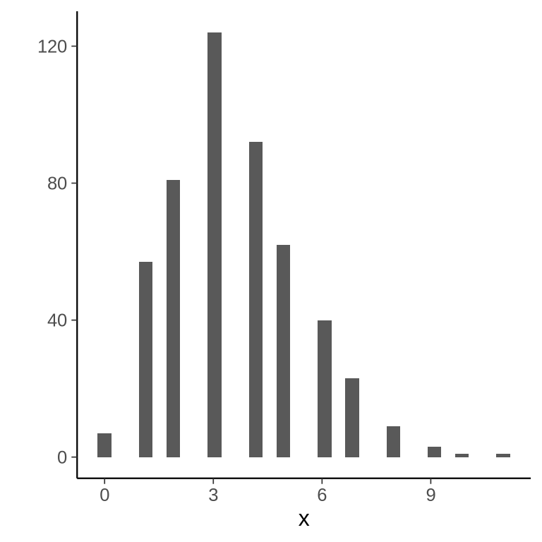

```r
x <- rpois(N, mean(y))
qplot(x)
```

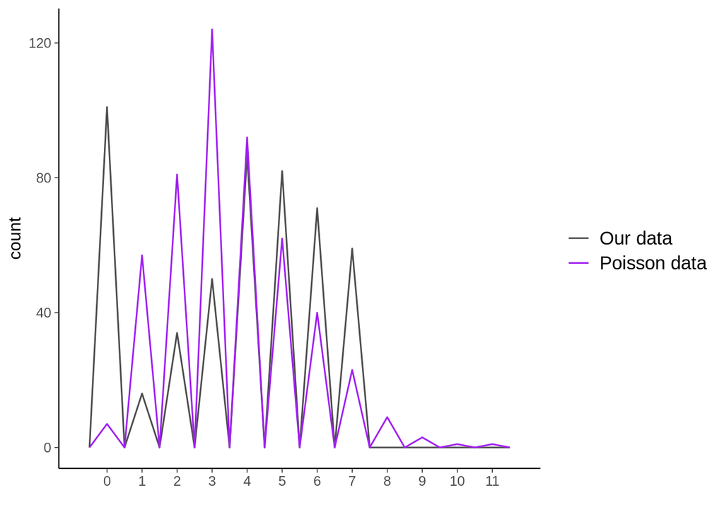

```r
plotdata <- data.frame(
  value = c(y, x),
  variable = rep(c("Our data", "Poisson data"), each = N)
)
ggplot(plotdata, aes(x = value, color = variable)) +
  geom_freqpoly(binwidth = 0.5) +
  scale_x_continuous(name = "", breaks = 0:max(x,y)) +
  scale_color_manual(name = "", values = c("gray30", "purple"))
```

# 2 Fit basic Poisson model

Even though we already suspect it won’t be a good model for this data, it’s still a good idea to start by fitting the simplest Poisson model. From there we can then identify in which ways the model is inadequate.

```r
code_poisson <- root("demos_rstan/ppc", "poisson-simple.stan")
writeLines(readLines(code_poisson))
```

```
data {
  int<lower=1> N;
  array[N] int<lower=0> y;
}
parameters {
  real<lower=0> lambda;
}
model {
  lambda ~ exponential(0.2);
  y ~ poisson(lambda);
}
generated quantities {
  array[N] real log_lik;
  array[N] int y_rep;
  for (n in 1 : N) {
    y_rep[n] = poisson_rng(lambda);
    log_lik[n] = poisson_lpmf(y[n] | lambda);
  }
}
```

```r
fit <- stan(file = code_poisson, data = c("y", "N"), refresh = 0)
monitor(as.array(fit)[,,c("lambda","lp__")])
```

```
Inference for the input samples (4 chains: each with iter = 1000; warmup = 500):

          Q5   Q50   Q95  Mean  SD  Rhat Bulk_ESS Tail_ESS
lambda   3.5   3.7   3.8   3.7 0.1     1      836     1273
lp__   544.3 546.0 546.2 545.7 0.7     1     1087     1313

For each parameter, Bulk_ESS and Tail_ESS are crude measures of
effective sample size for bulk and tail quantities respectively (an ESS > 100
per chain is considered good), and Rhat is the potential scale reduction
factor on rank normalized split chains (at convergence, Rhat <= 1.05).
```

## 2.1 Look at posterior distribution of lambda

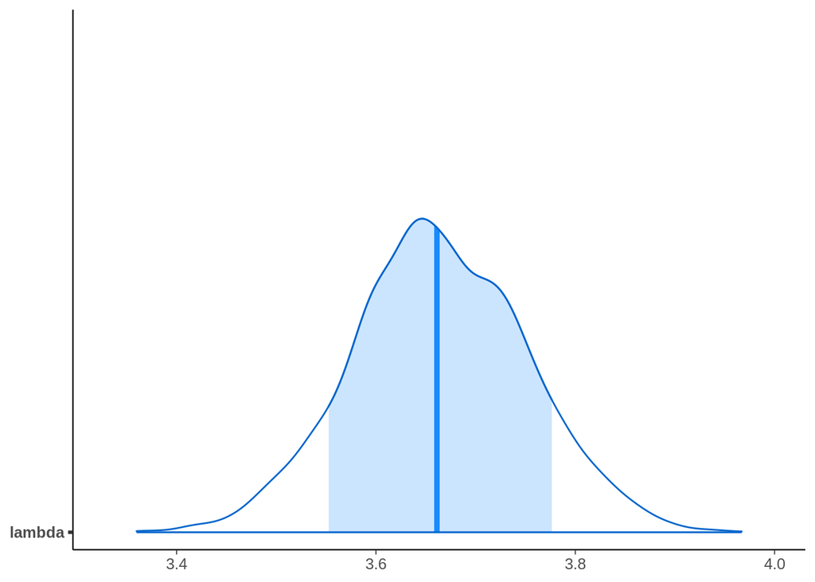

```r
color_scheme_set("brightblue") # check out ?bayesplot::color_scheme_set
lambda_draws <- as.matrix(fit, pars = "lambda")
mcmc_areas(lambda_draws, prob = 0.8) # color 80% interval
```

## 2.2 Check summary of lambda and compare to mean of the data

```r
print(fit, pars = "lambda")
```

```
Inference for Stan model: anon_model.
4 chains, each with iter=2000; warmup=1000; thin=1;
post-warmup draws per chain=1000, total post-warmup draws=4000.

       mean se_mean   sd 2.5%  25%  50%  75% 97.5% n_eff Rhat
lambda 3.66       0 0.09 3.49 3.61 3.66 3.72  3.84  1688    1

Samples were drawn using NUTS(diag_e) at Thu Oct 22 15:52:01 2026.
For each parameter, n_eff is a crude measure of effective sample size,
and Rhat is the potential scale reduction factor on split chains (at
convergence, Rhat=1).
```

```r
mean(y)
```

```
[1] 3.662
```

The model gets the mean right, but, as we’ll see next, the model is quite bad at predicting the outcome.

# 3 Graphical posterior predictive checks

## 3.1 Extract `y_rep` draws from the fitted model object

```r
y_rep <- as.matrix(fit, pars = "y_rep")

# number of rows = number of post-warmup posterior draws
# number of columns = length(y)
dim(y_rep)
```

```
[1] 4000  500
```

## 3.2 Compare histogram of `y` to histograms of several `y_rep`s

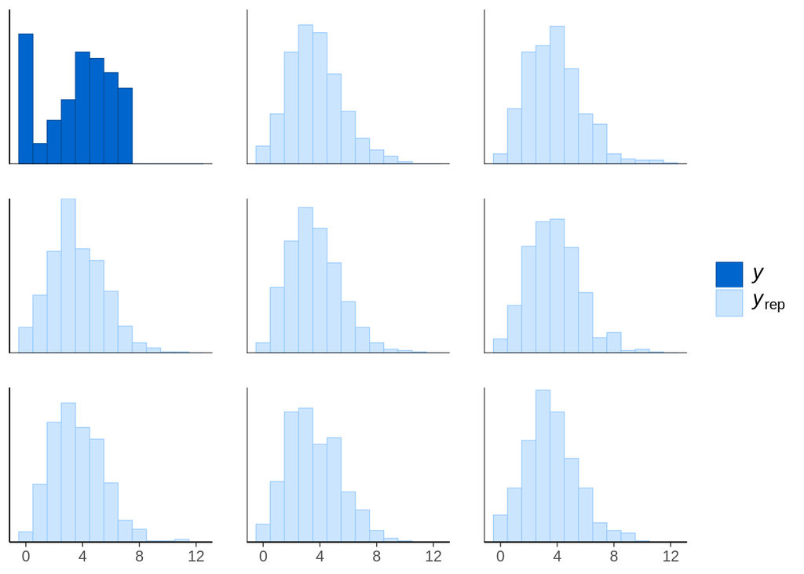

```r
ppc_hist(y, y_rep[1:8, ], binwidth = 1)
```

## 3.3 Compare density estimate of `y` to density estimates of a bunch of `y_rep`s

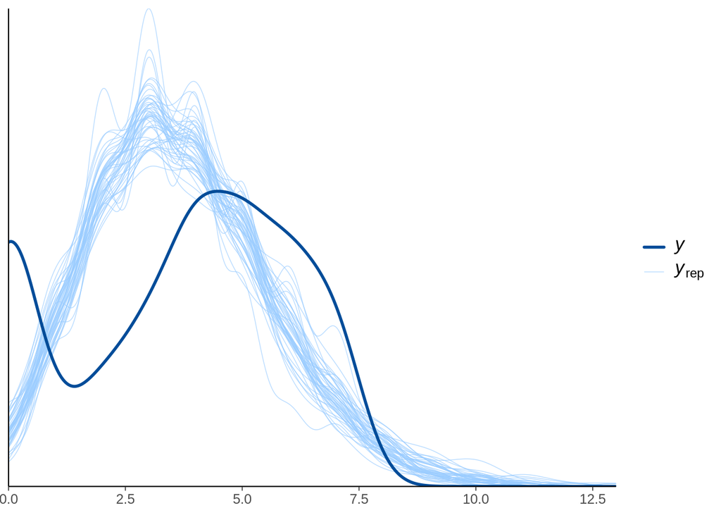

```r
ppc_dens_overlay(y, y_rep[1:50, ])
```

## 3.4 Rootograms

Rootograms are a graphical tool to assess the fit of count data models (Tukey 1977; Kleiber and Zeileis 2016). There are a few variations of this type of plots. For the one presented here we use the square root of the frequency (the number of observations with each count value) on the y-axis. The square root scale makes it easier to compare observed and expected frequencies, even for low frequencies. The observed data are represented by points, while the model predictions are shown as point-intervals. Squares indicate that the observed data match the model predictions within the uncertainty intervals, and diamonds indicate that the observed data fall outside the predictive intervals.

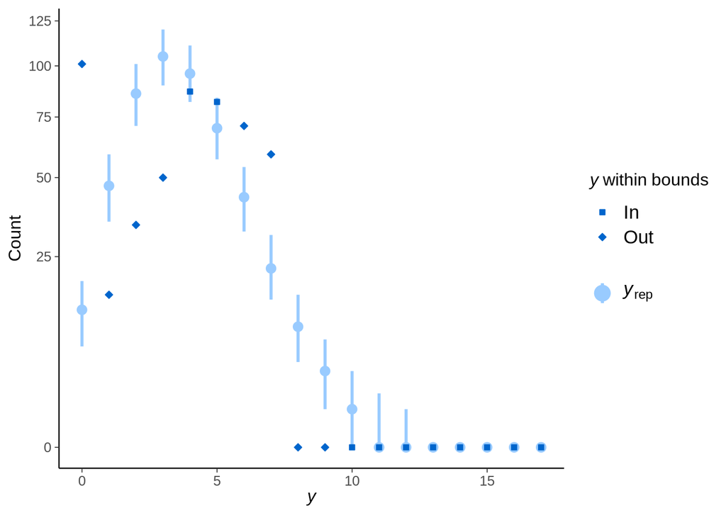

```r
ppc_rootogram(y, y_rep, style="discrete")
```

## 3.5 Compare proportion of zeros in `y` to the distribution of that proportion over all `y_rep`s

```r
prop_zero <- function(x) mean(x == 0)
print(prop_zero(y))
```

```
[1] 0.202
```

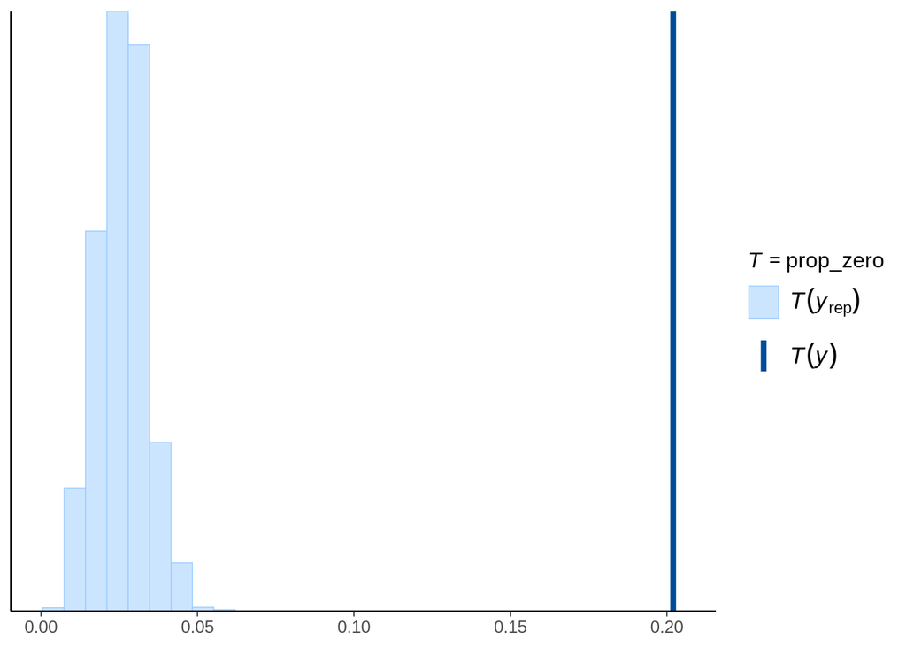

```r
ppc_stat(y, y_rep, stat = "prop_zero")
```

## 3.6 Some other checks

Look at two statistics in a scatterplot:

```r
ppc_stat_2d(y, y_rep, stat = c("mean", "sd"))
```

```
Note: in most cases the default test statistic 'mean' is too weak to detect anything of interest.
```

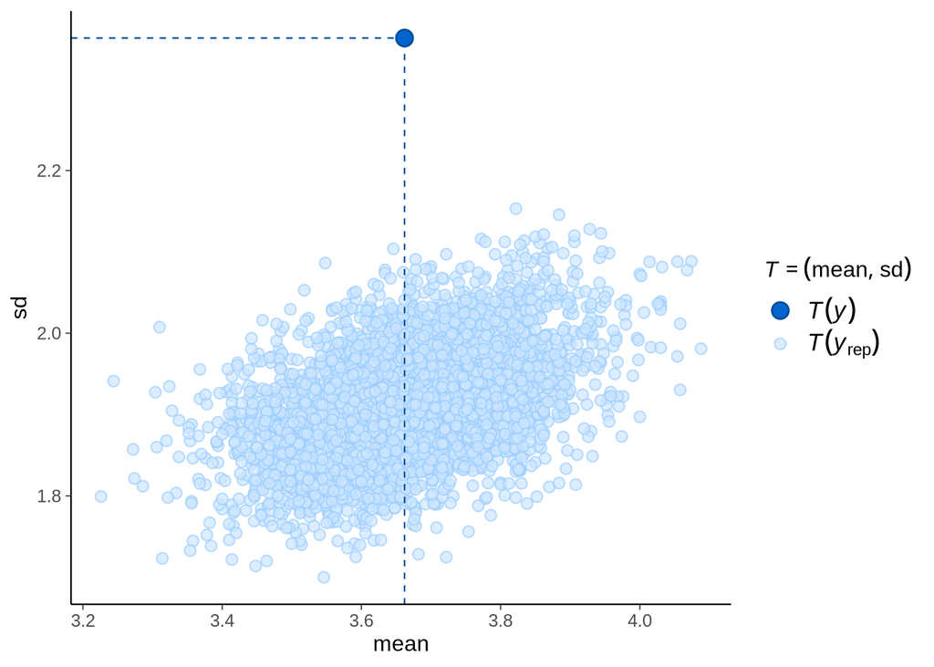

Distributions of predictive errors:

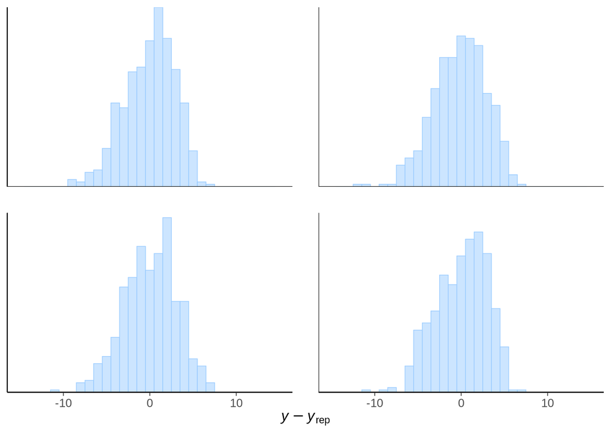

```r
ppc_error_hist(y, y_rep[1:4, ], binwidth = 1) + xlim(-15, 15)
```

# 4 Fit Poisson “hurdle” model (also with truncation from above)

This model says that there is some probability `theta` that `y` is zero and probability `1 - theta` that `y` is positive. Conditional on observing a positive `y`, we use a truncated Poisson

```
y[n] ~ Poisson(lambda) T[1, U];
```

where `T[1,U]` indicates truncation with lower bound `1` and upper bound `U`, which for simplicity we’ll *assume* is `max(y)`.

```r
code_poisson_hurdle <- root("demos_rstan/ppc", "poisson-hurdle.stan")
writeLines(readLines(code_poisson_hurdle))
```

```
/* Poisson "hurdle" model (also with upper truncation)
 *
 * Note: for simplicity I assume that there is only one way to obtain
 * a zero, as opposed to some zero-inflated models where there are
 * multiple processes that lead to a zero. So in this example, y is
 * zero with probability theta and y is modeled as a truncated poisson
 * if greater than zero.
 */

data {
  int<lower=1> N;
  array[N] int<lower=0> y;
}
transformed data {
  int U = max(y); // upper truncation point
}
parameters {
  real<lower=0, upper=1> theta; // Pr(y = 0)
  real<lower=0> lambda; // Poisson rate parameter (if y > 0)
}
model {
  lambda ~ exponential(0.2);

  for (n in 1 : N) {
    if (y[n] == 0) {
      target += log(theta); // log(Pr(y = 0))
    } else {
      target += log1m(theta); // log(Pr(y > 0))
      y[n] ~ poisson(lambda) T[1, U]; // truncated poisson
    }
  }
}
generated quantities {
  array[N] real log_lik;
  array[N] int y_rep;
  for (n in 1 : N) {
    if (bernoulli_rng(theta)) {
      y_rep[n] = 0;
    } else {
      // use a while loop because Stan doesn't have truncated RNGs
      int w; // temporary variable
      w = poisson_rng(lambda);
      while (w == 0 || w > U) {
        w = poisson_rng(lambda);
      }

      y_rep[n] = w;
    }
    if (y[n] == 0) {
      log_lik[n] = log(theta);
    } else {
      log_lik[n] = log1m(theta) + poisson_lpmf(y[n] | lambda)
                   - log_diff_exp(poisson_lcdf(U | lambda),
                                  poisson_lcdf(0 | lambda));
    }
  }
}
```

```r
fit2 <- stan(file = code_poisson_hurdle, data = c("y", "N"), refresh = 0)
```

```r
print(fit2, pars = c("lambda", "theta"))
```

```
Inference for Stan model: anon_model.
4 chains, each with iter=2000; warmup=1000; thin=1;
post-warmup draws per chain=1000, total post-warmup draws=4000.

       mean se_mean   sd 2.5%  25% 50%  75% 97.5% n_eff Rhat
lambda 5.31       0 0.16 5.00 5.20 5.3 5.42  5.64  3609    1
theta  0.20       0 0.02 0.17 0.19 0.2 0.22  0.24  2891    1

Samples were drawn using NUTS(diag_e) at Thu Oct 22 15:52:42 2026.
For each parameter, n_eff is a crude measure of effective sample size,
and Rhat is the potential scale reduction factor on split chains (at
convergence, Rhat=1).
```

## 4.1 Compare posterior distributions of lambda from the two models

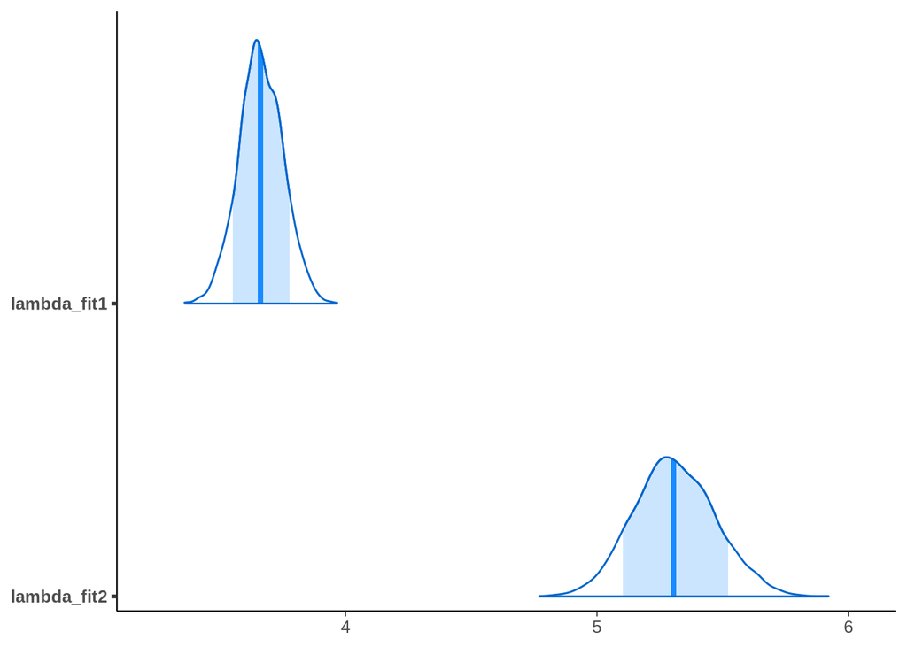

```r
lambda_draws2 <- as.matrix(fit2, pars = "lambda")
lambdas <- cbind(lambda_fit1 = lambda_draws[, 1],
                 lambda_fit2 = lambda_draws2[, 1])
mcmc_areas(lambdas, prob = 0.8) # color 80% interval
```

# 5 Posterior predictive checks again

Same plots as before (and a few others), but this time using `y_rep` from `fit2`. Everything looks much more reasonable:

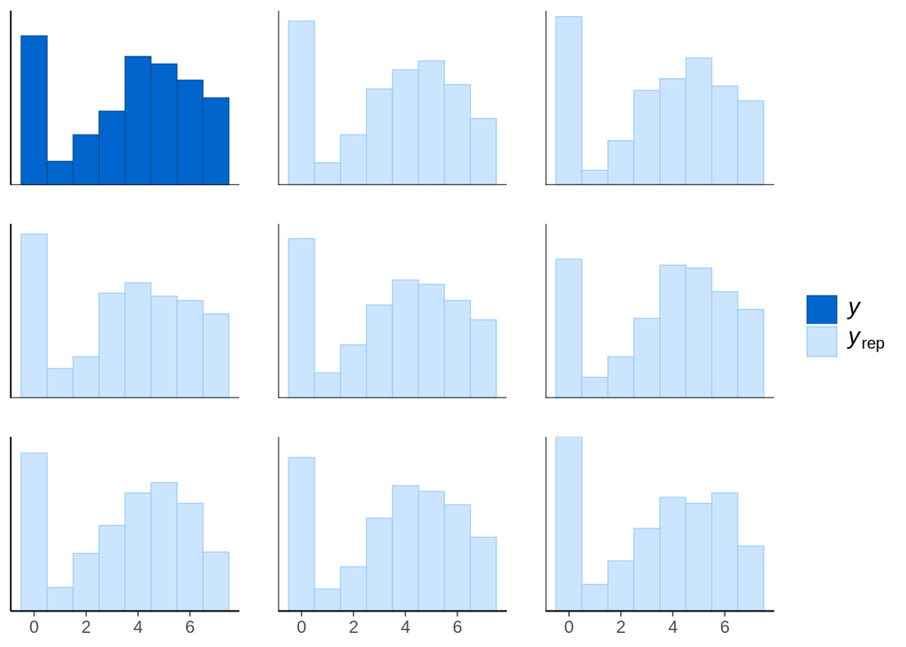

```r
y_rep2 <- as.matrix(fit2, pars = "y_rep")
ppc_hist(y, y_rep2[1:8, ], binwidth = 1)
```

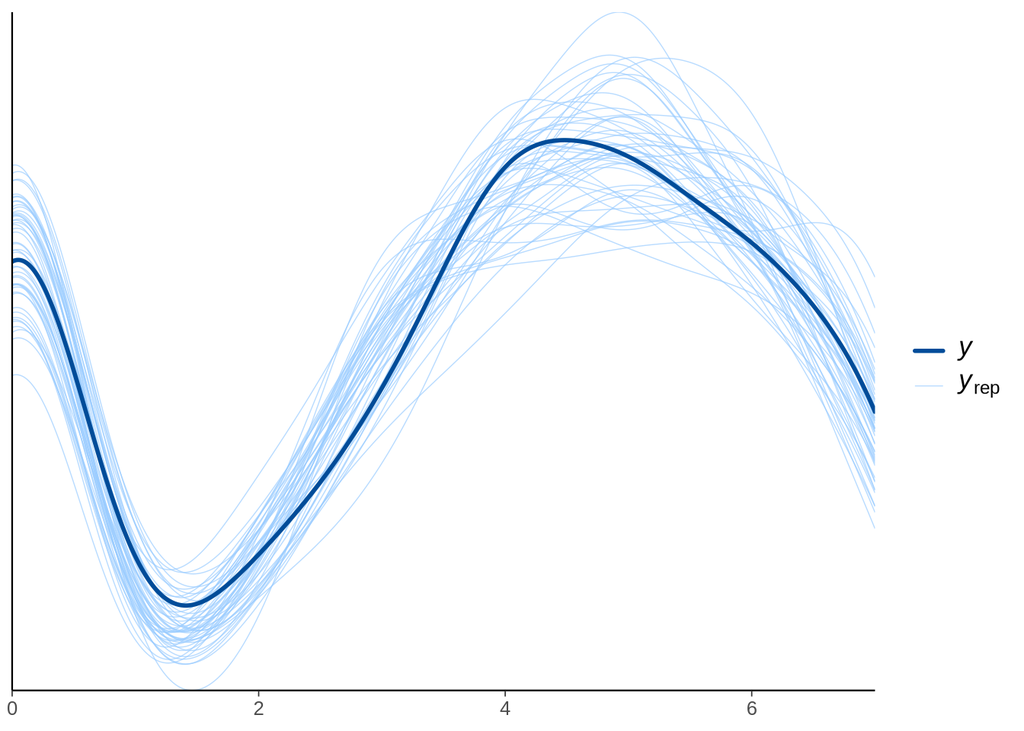

```r
ppc_dens_overlay(y, y_rep2[1:50, ])
```

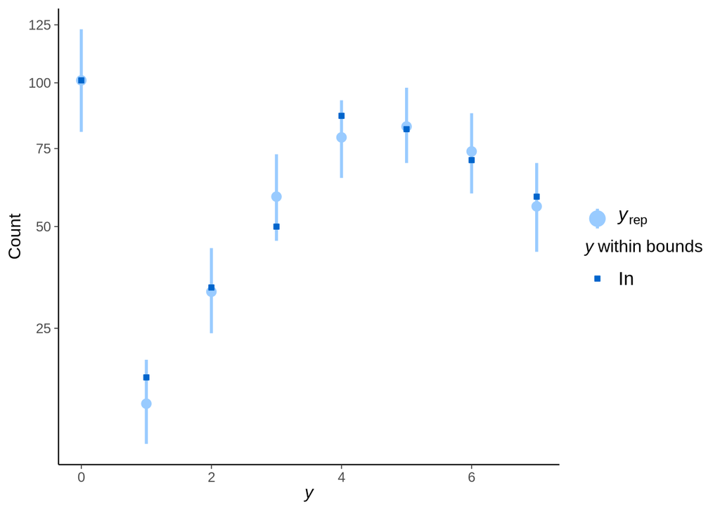

```r
ppc_rootogram(y, y_rep2, style="discrete")
```

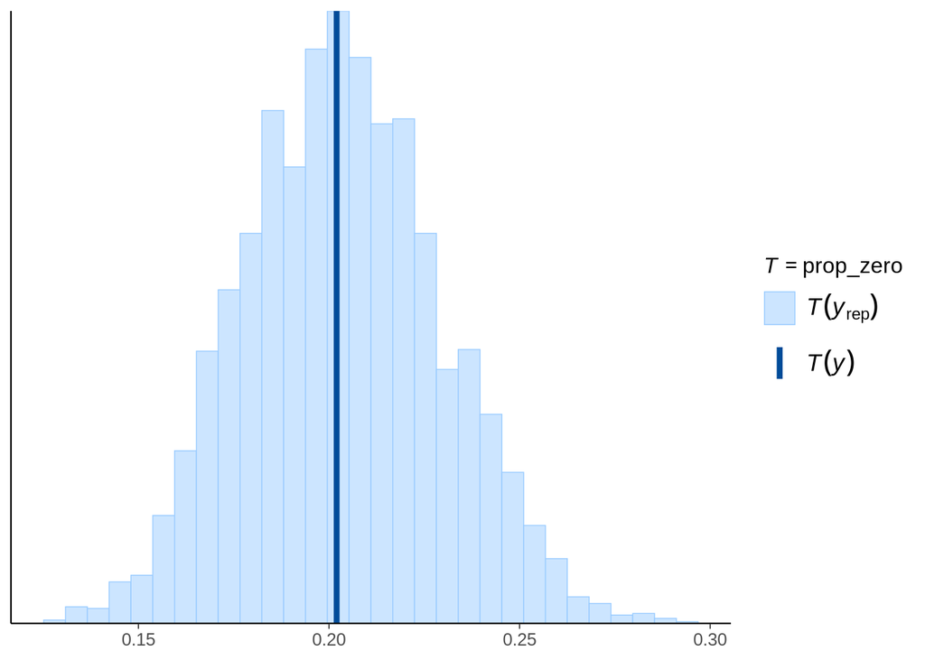

```r
ppc_stat(y, y_rep2, stat = "prop_zero")
```

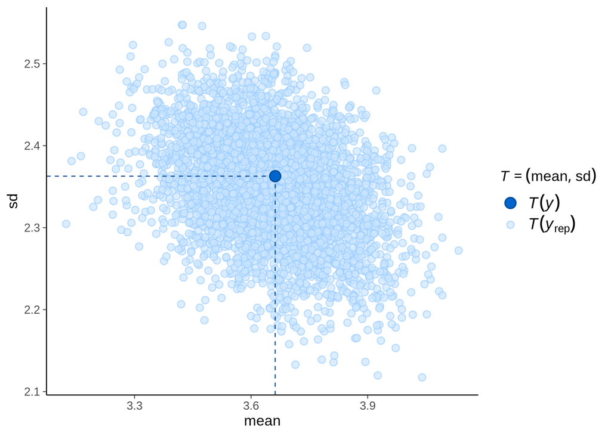

```r
ppc_stat_2d(y, y_rep2, stat = c("mean", "sd"))
```

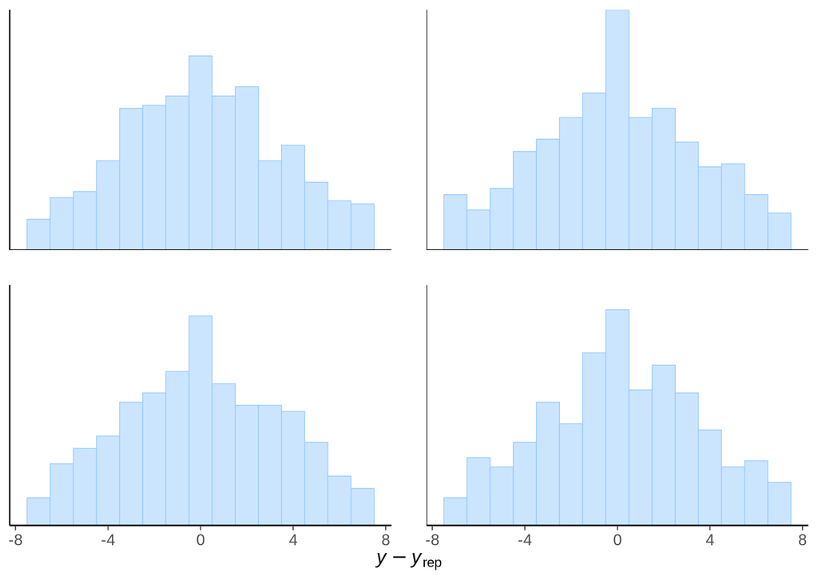

```r
ppc_error_hist(y, y_rep2[sample(nrow(y_rep2), 4), ], binwidth = 1)
```

# 6 Comparison with leave-one-out cross-validation

Compare predictive performance with LOO.

```r
(loo1 <- loo(fit))
```

```
Computed from 4000 by 500 log-likelihood matrix.

         Estimate   SE
elpd_loo  -1208.0 17.5
p_loo         1.6  0.1
looic      2416.0 35.0
------
MCSE of elpd_loo is 0.0.
MCSE and ESS estimates assume MCMC draws (r_eff in [0.4, 0.4]).

All Pareto k estimates are good (k < 0.7).
See help('pareto-k-diagnostic') for details.
```

```r
(loo2 <- loo(fit2))
```

```
Computed from 4000 by 500 log-likelihood matrix.

         Estimate   SE
elpd_loo   -992.0  9.4
p_loo         2.0  0.1
looic      1984.0 18.7
------
MCSE of elpd_loo is 0.0.
MCSE and ESS estimates assume MCMC draws (r_eff in [0.7, 0.9]).

All Pareto k estimates are good (k < 0.7).
See help('pareto-k-diagnostic') for details.
```

```r
loo_compare(loo1, loo2)
```

```
       elpd_diff se_diff
model2    0.0       0.0
model1 -216.0      22.1
```

Model 2 is a clear winner in the predictive performance.

# References

- Kleiber, C. and Zeileis, A. (2016). Visualizing count data regressions using rootograms. *The American Statistician*, 70(3):296-303. [doi:10.1080/00031305.2016.1173590](https://doi.org/10.1080/00031305.2016.1173590)
- Tukey, J. W. (1977). *Exploratory Data Analysis*. 1st edition. Pearson.